# CSE 676 - Deep Learning

# Final Project

### Applying Diffusion Algorithms for Graph Learning

Name: **Arthav Mane**

UBID: **50426537**

Github: https://github.com/arthavmane/DL-learning-Project

# Specification of Problems

Graph Neural Networks (GNN) usually implement Graph Convolution that approximates values by message passing between neighboring nodes.

This limits the networks from looking at the graph as a whole and getting deeper insight into the data.

In this project, a recently proposed novel graph diffusion algorithm is implemented that implements a spacially localized graph convolution.

The graph diffusion is used for the task of node classification for few datasets.

The results reproduced from implemented and the results mentioned in paper are found to be similar.

# What is Graph Learning?

## Graph Data

- Graphs are basically connections that shows relations (sometimes with importance i.e. weights) between entities.
- Graph data is rife in our everyday life
- Examples: social networks, citations, physical models, organizations, transactions, molecules, etc.

Different types of problems:

- Node classification
- Node clustering
- Graph classification
- Link prediction

## Graph Convolution

Just like Convolutional Neural Networks (CNN), we can perform convolutions on layers for graph data as well.

This is because images can be considered as graphs of pixels connected throughout multiple dimensions.

Each pixel in an image can be considered to be a node with edges to its neighboring pixels in all channels.

# State-of-the-art Models

## Graph Convolutional Networks

Adapted from [Semi-Supervised Classification with Graph Convolutional Networks](https://arxiv.org/abs/1609.02907)

Implemented using `pytorch` and `pytorch-geometric`

Activation: ReLU

Dropout: 0.5

Output activation: LogSoftmax

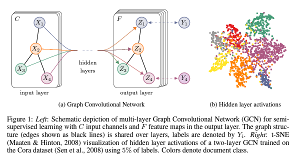

Source: [Semi-Supervised Classification with Graph Convolutional Networks](https://arxiv.org/abs/1609.02907)

```
class GCN(nn.Module):

    def __init__(self, dataset, depth, hid_dim=64):
        super(GCN, self).__init__()
        num_features = [dataset.data.x.shape[1]] + [hid_dim]*depth + [dataset.num_classes]
        self.layers = nn.ModuleList()
        for in_features, out_features in zip(num_features[:-1], num_features[1:]):
            self.layers.append( GCNConv(in_features, out_features) )

        self.reg_params = list(self.layers[0].parameters())
        self.non_reg_params = list([p for l in self.layers[1:] for p in l.parameters()])

        self.activation = nn.ReLU()
        self.dropout = nn.Dropout(p=DROPOUT)
        self.to(device)

    def reset_parameters(self):
        for l in self.layers:
            l.reset_parameters()

    def forward(self, input_data):
        x, edge_index, edge_attr = input_data.x, input_data.edge_index, input_data.edge_attr
        for layer in self.layers[:-1]:
            x = layer(x, edge_index, edge_weight=edge_attr)
            x = self.activation(x)
            x = self.dropout(x)
        x = self.layers[-1](x, edge_index, edge_weight=edge_attr)
        x = nn.LogSoftmax(dim=1)(x)
        return x
```

## Graph Attention Networks

Adapted from [Graph Attention Networks](https://arxiv.org/abs/1710.10903)

Implemented using `pytorch` and `pytorch-geometric`

Activation: ELU

Dropout: 0.5

Output activation: LogSoftmax

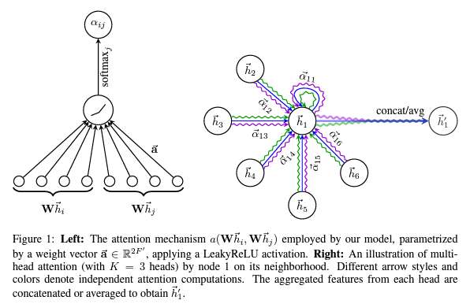

Source: [Graph Attention Networks](https://arxiv.org/abs/1710.10903)

```
class GAT(nn.Module):

    def __init__(self, dataset, depth, hid_dim=64):
        super(GAT, self).__init__()
        num_features = [hid_dim]*depth
        h = 1
        self.layers = nn.ModuleList()
        self.layers.append( GATConv(dataset.data.x.shape[1], hid_dim, heads=h) )
        for _ in range(depth-1):
            self.layers.append( GATConv(hid_dim*h, hid_dim, heads=h) )
        self.layers.append( GATConv(hid_dim*h, dataset.num_classes, concat=False) )

        self.reg_params = list(self.layers[0].parameters())
        self.non_reg_params = list([p for l in self.layers[1:] for p in l.parameters()])

        self.activation = nn.ELU()
        self.dropout = nn.Dropout(p=DROPOUT)
        self.to(device)

    def reset_parameters(self):
        for l in self.layers:
            l.reset_parameters()

    def forward(self, input_data):
        x, edge_index, edge_attr = input_data.x, input_data.edge_index, input_data.edge_attr
        for layer in self.layers[:-1]:
            x = layer(x, edge_index, edge_attr=edge_attr)
            x = self.activation(x)
            x = self.dropout(x)
        x = self.layers[-1](x, edge_index, edge_attr=edge_attr)
        x = nn.LogSoftmax(dim=1)(x)
        return x
```

## Jumping Knowledge

Adapted from [Representation Learning on Graphs with Jumping Knowledge Networks](https://arxiv.org/abs/1806.03536)

Implemented using `pytorch` and `pytorch-geometric`

Activation: ReLU

Dropout: 0.5

Output activation: LogSoftmax

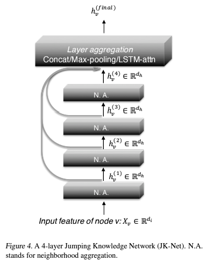

Source: [Representation Learning on Graphs with Jumping Knowledge Networks](https://arxiv.org/abs/1806.03536)

```
class JK(nn.Module):

    def __init__(self, dataset, depth):
        super(JK, self).__init__()
        num_features = [dataset.data.x.shape[1]] + [64]*depth
        self.layers = nn.ModuleList()
        for in_features, out_features in zip(num_features[:-1], num_features[1:]):
            self.layers.append( GCNConv(in_features, out_features) )
        self.layers.append( nn.Linear(64*depth, dataset.num_classes) )

        self.reg_params = list(self.layers[0].parameters())
        self.non_reg_params = list([p for l in self.layers[1:] for p in l.parameters()])

        self.activation = nn.ReLU()
        self.dropout = nn.Dropout(p=DROPOUT)
        self.to(device)

    def reset_parameters(self):
        for l in self.layers:
            l.reset_parameters()

    def forward(self, input_data):
        layer_outputs = []
        x, edge_index, edge_attr = input_data.x, input_data.edge_index, input_data.edge_attr
        for layer in self.layers[:-1]:
            x = layer(x, edge_index, edge_weight=edge_attr)
            x = self.activation(x)
            x = self.dropout(x)
            layer_outputs.append(x)
        x = torch.cat(layer_outputs, dim=-1)
        x = self.layers[-1](x)
        x = nn.LogSoftmax(dim=1)(x)
        return x
```

# Graph Diffusion

In this project, the Graph Diffusion Convolution (GDC) algorithm from the paper [Diffusion Improves Graph Learning](https://arxiv.org/abs/1911.05485) is implemented.

GDC can be used to preprocess data and can be combined with an form of Message Passing Neural Networks (MPNN) and Graph Neaural Networks (GNN).

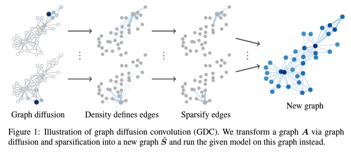

Source: [Diffusion Improves Graph Learning](https://arxiv.org/abs/1911.05485)

There are 2 types of Graph Diffusion:

- Heat kernel diffusion
- Personalized Page Rank (PPR)

```
def apply_graph_diffusion(dataset, method, t=5.0, alpha=0.1, k=None, eps=None):
    """
    Apply the graph diffusion algorithm from "Diffusion Improves Graph Learning" <https://arxiv.org/abs/1911.05485> paper.
    """
    total_nodes = dataset.data.x.shape[0]

    # compute adjaceny matrix from spare representation of graph data
    adjacency_matrix = torch.zeros((total_nodes, total_nodes))
    for i,j in zip(dataset.data.edge_index[0], dataset.data.edge_index[1]):
        adjacency_matrix[i,j] = 1

    # self-loops
    A = adjacency_matrix + torch.eye(total_nodes)

    # symmetric transition matrix
    D = torch.diag( 1 / torch.sqrt(A.sum(axis=1)) )
    T_sym = D @ A @ D

    # apply graph diffusion
    if method == 'heat':
        diffusion_matrix = torch.matrix_exp( -t * ( torch.eye(total_nodes) - T_sym ))
    elif method == 'ppr':
        diffusion_matrix = alpha * torch.inverse( torch.eye(total_nodes) - (1 - alpha) * T_sym )

    # sparsify
    if k:
        rows = np.arange(total_nodes)
        diffusion_matrix[ diffusion_matrix.argsort(axis=0)[:total_nodes-k], rows] = 0
    elif eps:
        diffusion_matrix[diffusion_matrix < eps] = 0
    norm = diffusion_matrix.sum(axis=0)
    norm[norm <= 0] = 1
    diffusion_matrix /= norm


    # prepare new data for data obtained after applying graph diffusion
    edges_i, edges_j, edge_attr = [], [], []
    for i, row in enumerate(diffusion_matrix):
        for j in np.where(row > 0)[0]:
            edges_i.append(i)
            edges_j.append(j)
            edge_attr.append(diffusion_matrix[i,j])
    edge_index = [edges_i, edges_j]
    data = Data(x=dataset.data.x, y=dataset.data.y,
                edge_index=torch.LongTensor(edge_index),
                edge_attr=torch.FloatTensor(edge_attr),
                train_mask=torch.zeros(dataset.data.train_mask.size()[0], dtype=torch.bool),
                test_mask=torch.zeros(dataset.data.test_mask.size()[0], dtype=torch.bool),
                val_mask=torch.zeros(dataset.data.val_mask.size()[0], dtype=torch.bool))
    dataset.data = data

    return dataset
```

# Description of Datasets

**Datasets used in Paper:**

- Cora
- CiteSeer
- PubMed
- CoAuthor CS
- Amazon Computers
- Amazon Photo

**Datasets used in Project:**

- Cora
- CiteSeer
- Amazon Photo

## Cora

Cora is a citation network dataset.

Included in `pytorch-geometric` library.

Dataset obtained as follows:

```
from torch_geometric.datasets import Planetoid
cora = Planetoid(root_path, "Cora")
```

Nodes -> documents

Edges -> citation links

Stats:

- No. of Nodes: 2,708
- No. of Edges: 10,556
- No. of Features: 1,433
- No. of Classes: 7

## CiteSeer

CiteSeer is also a citation network dataset.

Included in `pytorch-geometric` library.

Dataset obtained as follows:

```
from torch_geometric.datasets import Planetoid
citeseer = Planetoid(root_path, "Citeseer")
```

Nodes -> documents

Edges -> citation links

Stats:

- No. of Nodes: 3,327
- No. of Edges: 9,104
- No. of Features: 3,703
- No. of Classes: 6

## Amazon Photo

Amazon Photo is a product dataset.

Included in `pytorch-geometric` library.

Dataset obtained as follows:

```
from torch_geometric.datasets import Amazon
photo = Amazon(root_path, "Photo")
```

Nodes -> goods

Edges -> link between two goods frequently bought together

Given product reviews as bag-of-words, the task is to map goods to their respective product category

Stats:

- No. of Nodes: 7,650
- No. of Edges: 238,162
- No. of Features: 745
- No. of Classes: 8

# Implementation

## Data Preprocessing

- As mentioned earlier, the dataset is obtained from the `pytorch-geometric` library.
- For each dataset, we only use the largest connected components.
- The new data is then created using `torch_geometric.data.Data` with the updated edge indices and attributes.

```
def get_dataset(dataset_name):
    """
    Return the requested dataset with data containing only the largest connected components
    """

    # download/load dataset
    path = os.path.join(DATA_FOLDER, dataset_name)
    if dataset_name in ['Cora', 'Citeseer']:
        dataset = Planetoid(root=path, name=dataset_name)
    elif dataset_name in ['Photo']:
        dataset = Amazon(root=path, name=dataset_name)

    #select the largest connected components
    nodes = set(range(dataset.data.x.shape[0]))
    connected_components = []
    while nodes:
        begin = min(nodes)
        conn_comps, queue = set(), set([begin])
        row, col = dataset.data.edge_index.numpy()
        while queue:
            current = queue.pop()
            conn_comps.update([current])
            neighbors = []
            for n in col[np.where(row == current)[0]]:
                if n not in conn_comps and n not in queue:
                    neighbors.append(n)
            queue.update(neighbors)
        connected_components.append(conn_comps)
        nodes = nodes.difference(conn_comps)
    lcc_node_idx = np.argmax(list(map(len, connected_components)))
    lcc_nodes = np.array(list(connected_components[lcc_node_idx]))

    lcc_counter = {}
    c = 0
    for n in lcc_nodes:
        lcc_counter[n] = c
        c += 1

    # prepare new data to containing the largest connected components
    lcc_x, lcc_y = dataset.data.x[lcc_nodes], dataset.data.y[lcc_nodes]
    row, col = dataset.data.edge_index.numpy()
    edges = [(i,j) for i,j in zip(row,col) if i in lcc_nodes and j in lcc_nodes]
    r, c = zip(*edges)
    edges = [list(map(lambda x: lcc_counter[x], r)), list(map(lambda x: lcc_counter[x], c))]
    lcc_data = Data(x=lcc_x, y=lcc_y, edge_index=torch.LongTensor(edges),
                train_mask=torch.zeros(lcc_y.size()[0], dtype=torch.bool),
                test_mask=torch.zeros(lcc_y.size()[0], dtype=torch.bool),
                val_mask=torch.zeros(lcc_y.size()[0], dtype=torch.bool))
    dataset.data = lcc_data

    return dataset
```

## Spliting Data

```
def split_data(data, seed, num_dev_nodes=1500):
    """
    Split the data (nodes) into training, validation and test nodes.
    This is done by modifying the train_, val_ and test_ masks according to the respective indices.
    """
    random = np.random.RandomState(development_seed)
    total_nodes = data.y.shape[0]
    dev_idx = random.choice(total_nodes, num_dev_nodes, replace=False)
    test_idx = [i for i in np.arange(total_nodes) if i not in dev_idx]

    random = np.random.RandomState(seed)
    train_idx = []
    for i in range(data.y.max()+1):
        class_idx = dev_idx[np.where(data.y[dev_idx].cpu() == i)[0]]
        train_idx.extend(random.choice(class_idx, 20, replace=False))

    val_idx = [i for i in dev_idx if i not in train_idx]

    data.train_mask = torch.zeros(total_nodes, dtype=torch.bool)
    data.train_mask[train_idx] = 1
    data.val_mask = torch.zeros(total_nodes, dtype=torch.bool)
    data.val_mask[val_idx] = 1
    data.test_mask = torch.zeros(total_nodes, dtype=torch.bool)
    data.test_mask[test_idx] = 1

    return data
```

For model optimization, Adam optimizer is used with a learning rate of 0.01. The previous gradients of the layers are cleared. The loss is calculated using the Negative Log Likelihood function. The loss calculated is then back propagated through the layers of the model and the model weights are tuned accordingly.

```
def train_model(model, optimizer, data):
    """
    Train model with backpropagation.
    """
    model.train()
    optimizer.zero_grad()
    output = model(data)
    loss = nn.NLLLoss()(output[data.train_mask], data.y[data.train_mask])
    loss.backward()
    optimizer.step()
```

```
def evaluate_model(model, data):
    """
    Evaluate model on the validation and test data.
    """
    model.eval()
    with torch.no_grad():
        output = model(data)
    evaluation = {}
    keys = ['val', 'test']
    for k in keys:
        mask = data[f'{k}_mask']
        pred = output[mask].max(1)[1]
        accuracy = pred.eq(data.y[mask]).sum().item() / mask.sum().item()
        evaluation[k] = accuracy
    return evaluation
```

## Run training process

- Adam optimizer is used for optimizing the model.
- The training process is run for a maximum of 10,000 epochs.
- Early stopping patience is set to 100 epochs.
- For every run the accuracy is calculated using 100 random splits of development set which is controlled by a set of 100 fixed seeds.
- Every time a better validation accuracy is obtained, the corresponding results are stored in a dictionary.

```
def run(dataset, model, seeds, diff_method, params):
    """
    Train and evalaute a model for a given dataset and diffusion method using the given params.
    """

    best_history = defaultdict(list)

    for seed in seeds:
        dataset.data = split_data(dataset.data, seed).to(device)
        model.reset_parameters()
        optimizer = optim.Adam(
            [
                {'params': model.non_reg_params, 'weight_decay': 0},
                {'params': model.reg_params, 'weight_decay': params['weight_decay']}
            ],
            lr = LEARNING_RATE
        )

        patience_ctr = 0
        temp = {'val': 0}

        for _ in range(10000):
            train_model(model, optimizer, dataset.data)
            evaluation = evaluate_model(model, dataset.data)

            if evaluation['val'] >= temp['val']:
                patience_ctr = 0
                temp['val'] = evaluation['val']
                temp['test'] = evaluation['test']
            else:
                patience_ctr += 1

            if patience_ctr == 100:
                break

        for k,v in temp.items():
            best_history[k].append(v)

    return dict(best_history)
```

## Running a model for each dataset and each diffusion method

```
def run_for_model(mname):
    """
    Run the algorithm for all dataset-diffusion combination for a given model.
    """

    with open('results.yaml', 'r') as file:
        saved_results = yaml.safe_load(file)

    for dname in DATASETS:
        print(f"\n{dname}")
        print(f"    {mname}")
        for diff in DIFFUSION_METHODS:
            params = CONFIG[mname][diff][dname]
            dataset = get_dataset(dname)
            if diff == 'heat':
                dataset = apply_graph_diffusion(dataset, 'heat', t=params['t'], k=params['k'], eps=params['eps'])
            elif diff == 'ppr':
                dataset = apply_graph_diffusion(dataset, 'ppr', alpha=params['alpha'], k=params['k'], eps=params['eps'])
            model = MODELS[mname](dataset, params['depth'])
            results[f"{dname}-{mname}-{diff}"] = run(dataset, model, test_seeds, diff, params)
            saved_results[dname][mname][diff] = float(np.round( 100*np.mean(results[f'{dname}-{mname}-{diff}']['test']), decimals=2 ))
            print(f"\t{diff}: {saved_results[dname][mname][diff]:.2f}")

    with open('results.yaml', 'w') as file:
        yaml.safe_dump(saved_results, file)
```

**GCN Hyperparameters**

```
none:
    Cora:
        weight_decay: 0.059
        depth: 1

    Citeseer:
        weight_decay: 10.0
        depth: 1

    Photo:
        weight_decay: 0.03
        depth: 1


heat:
    Cora:
        t: 5
        k:
        eps: 0.0001
        weight_decay: 0.086
        depth: 1

    Citeseer:
        t: 4
        k:
        eps: 0.0009
        weight_decay: 10.0
        depth: 1

    Photo:
        t: 3
        k:
        eps: 0.0001
        weight_decay: 0.08
        depth: 2

ppr:
    Cora:
        alpha: 0.05
        k: 128
        eps:
        weight_decay: 0.096
        depth: 1

    Citeseer:
        alpha: 0.10
        k:
        eps: 0.0009
        weight_decay: 10.0
        depth: 1

    Photo:
        alpha: 0.15
        k: 64
        eps:
        weight_decay: 0.03
        depth: 1
```

**GCN Output**

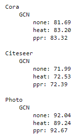

**GAT Hyperparameters**

```
none:
    Cora:
        weight_decay: 0.08
        depth: 1

    Citeseer:
        weight_decay: 0.08
        depth: 1

    Photo:
        weight_decay: 0.06
        depth: 1


heat:
    Cora:
        t: 1
        k:
        eps: 0.0010
        weight_decay: 0.04
        depth: 1

    Citeseer:
        t: 1
        k:
        eps: 0.0010
        weight_decay: 0.08
        depth: 1

    Photo:
        t: 1
        k:
        eps: 0.0005
        weight_decay: 0.01
        depth: 1

ppr:
    Cora:
        alpha: 0.10
        k:
        eps: 0.0050
        weight_decay: 0.08
        depth: 1

    Citeseer:
        alpha: 0.10
        k:
        eps: 0.0005
        weight_decay: 0.10
        depth: 1

    Photo:
        alpha: 0.10
        k:
        eps: 0.0005
        weight_decay: 0.07
        depth: 2
```

**GAT Output**

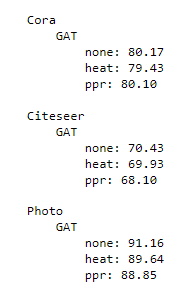

**JK Hyperparameters**

```
none:
    Cora:
        weight_decay: 0.04
        depth: 3

    Citeseer:
        weight_decay: 1.00
        depth: 4

    Photo:
        weight_decay: 0.03
        depth: 2


heat:
    Cora:
        t: 5
        k:
        eps: 0.0001
        weight_decay: 0.09
        depth: 2

    Citeseer:
        t: 4
        k:
        eps: 0.0009
        weight_decay: 1.00
        depth: 2

    Photo:
        t: 3
        k:
        eps: 0.0005
        weight_decay: 0.07
        depth: 2

ppr:
    Cora:
        alpha: 0.05
        k: 128
        eps:
        weight_decay: 0.10
        depth: 2

    Citeseer:
        alpha: 0.20
        k:
        eps: 0.0009
        weight_decay: 1.00
        depth: 2

    Photo:
        alpha: 0.15
        k: 64
        eps:
        weight_decay: 0.03
        depth: 2
```

**JK Output**

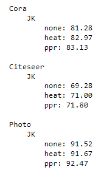

# Results

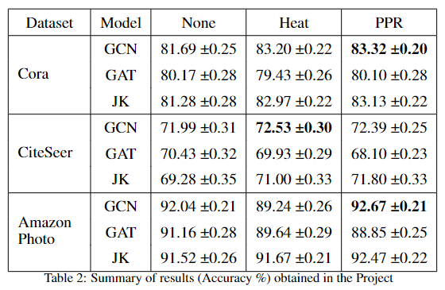

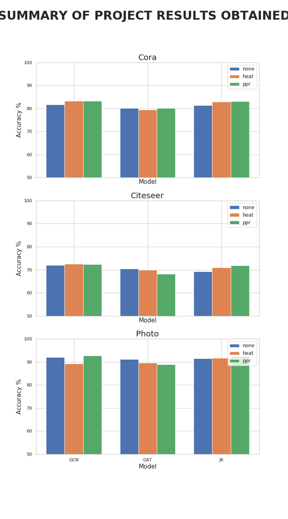

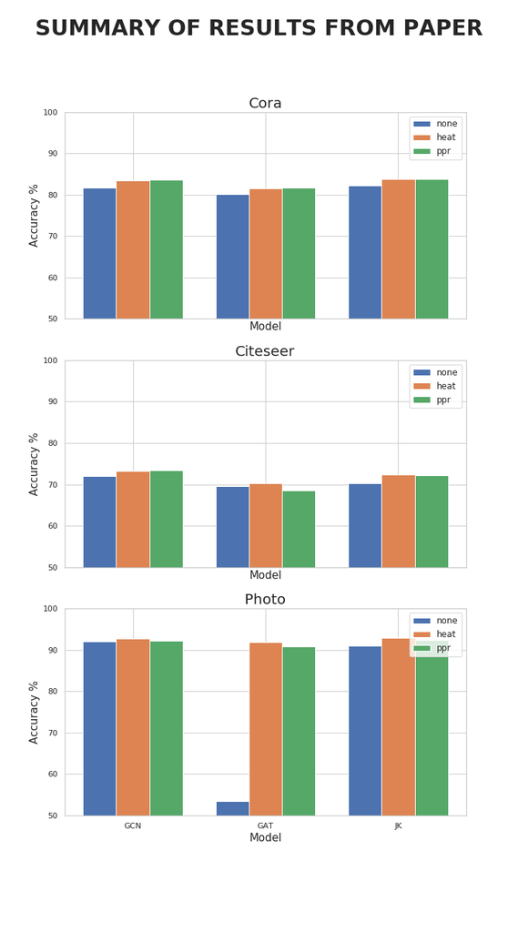

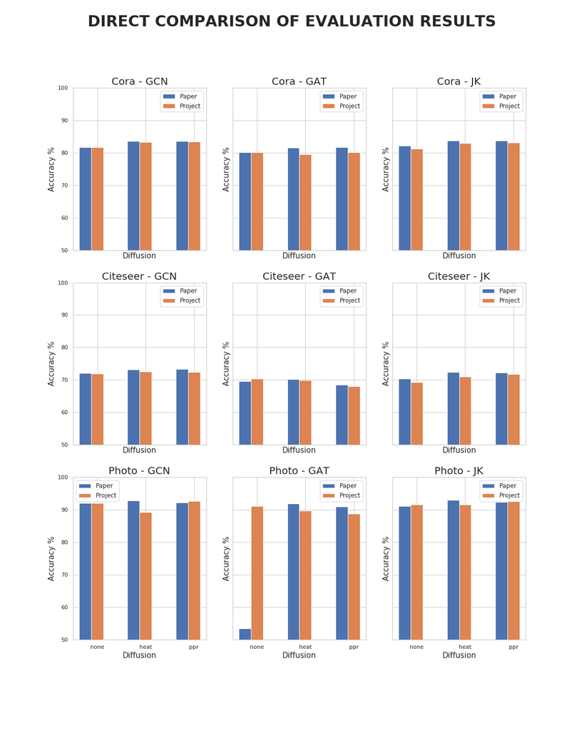

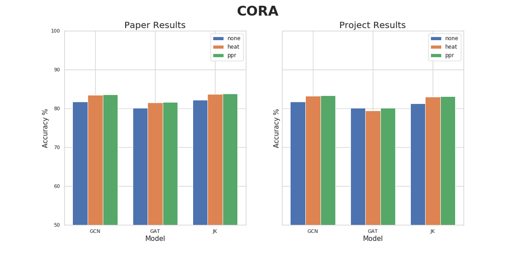

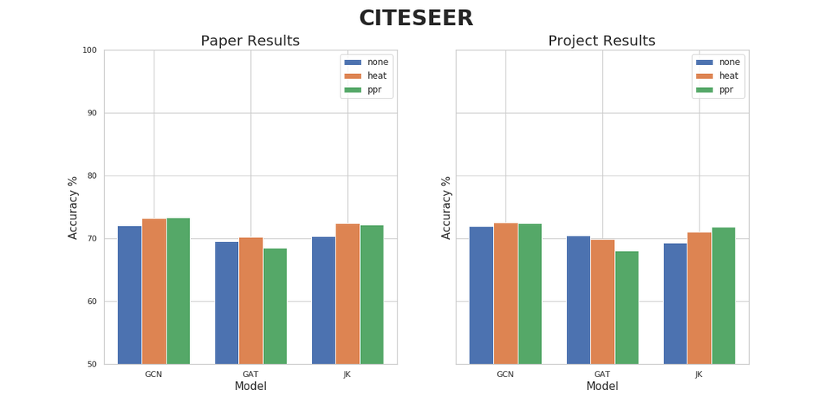

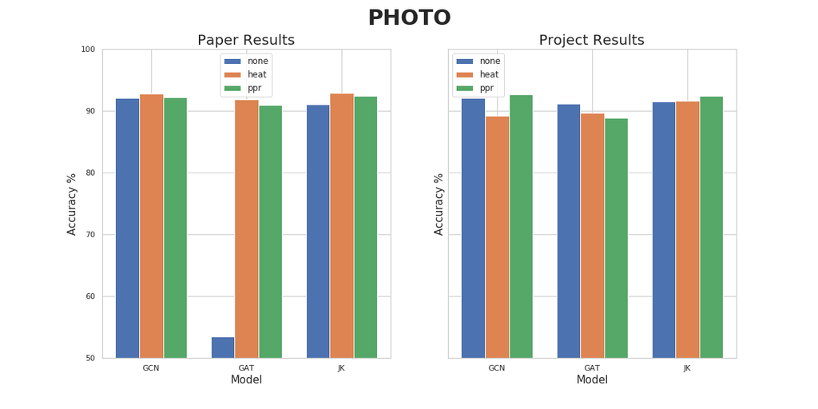

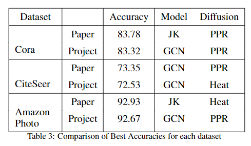

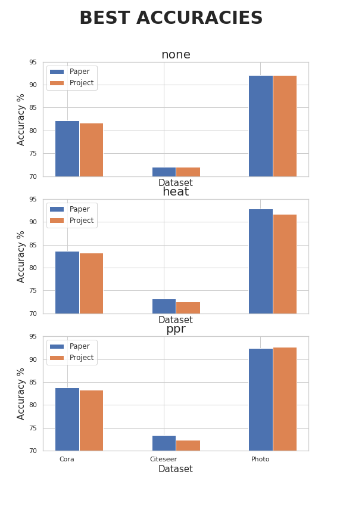

# Conclusion

GDC is a method based on sparsified graph diffusion which has good performance for node classification.

The results produced were almost similar to the ones mentioned in the result.

Differences in results might be because of differences in underlying/ backend seeds and hyperparameters.

The GDC algorithm is not very scalable.

For large datasets, sparse GDC is needed which is only available for the PPR diffusion method in `pytorch` currently.

## References:

- Paper: [Diffusion Improves Graph Learning](https://arxiv.org/abs/1911.05485)
- Official Code: https://github.com/gasteigerjo/gdc
- GCN: [Semi-Supervised Classification with Graph Convolutional Networks](https://arxiv.org/abs/1609.02907)
- GAT: [Graph Attention Networks](https://arxiv.org/abs/1710.10903)
- JK: [Representation Learning on Graphs with Jumping Knowledge Networks](https://arxiv.org/abs/1806.03536)